# Dragon Ball Supervised Learning Regression

## Problem Definition

"Can we accurately predict a Dragon Ball character's power level based on their race, transformations, combat skills, and abilities?"

### Context

- In the Dragon Ball universe, a character’s power level is a key indicator of their strength and battle potential.
- By using machine learning regression, we can estimate power levels based on different factors like transformations, combat abilities, and species traits.
- This could be useful for game balancing, fan discussions, and AI-generated character rankings.

### Objective

- Build a regression model to predict Power Level based on selected attributes.
- Identify key features that contribute the most to power level estimation.
- Analyze patterns in how different races, transformations, and fighting styles impact power levels.

## Data Dictionary

- **Name**: Character's name
- **Race**: The species of the fighter (Saiyan, Namekian, etc.)
- **Gender**: Male or Female
- **Power Level**: The numeric power level (Target Variable)
  - **Y Variable (Target)**
- **Ki Blast**: Character’s energy attack technique
- **Melee Combat**: Fighting style and close-combat abilities
- **Speed**: Speed level (Numeric)
- **Special Attack**: Ultimate moves or techniques
- **Transformation**: The highest transformation level achieved (Super Saiyan, etc.)
- **Speed_Original**: Descriptive speed category (Fast, Medium, Slow)
- **Normalized_Power**: Scaled power level (0-1)
- **Power_Score**: Normalized score based on battle metrics
- **Meta**: Combined metadata of character attributes

## Importing Libraries and the Dataset

```python
# Mounting the drive
from google.colab import drive
drive.mount('/content/drive')
```

```python
# Used to ignore the warning given as output of the code
import warnings                                       # Ignore the warning given as output of the code
warnings.filterwarnings('ignore')

# Basic libraries of python for numeric and dataframe computations
import numpy as np                                    # Basic libraries numeric and dataframe computations
import pandas as pd

# Import Matplotlib the Basic library for data visualization
# Import seaborn - Slightly advanced library for data visualization
import matplotlib.pyplot as plt                       # Basic visualization library
import seaborn as sns

# Import the required library to compute the cosine similarity between two vectors


# Import defaultdict from collections A dictionary output that does not raise a key error
from collections import defaultdict                   # A dictionary output that does not raise a key error
```

## Load the Dataset

```python
# Loading the ratings dataset
data = pd.read_csv('/content/drive/MyDrive/My DS DA/Dragon Ball Z/data.csv')
```

## Data Overview

```python
data.sample(5)
```

|  | Name | Race | Gender | Power Level | Ki Blast | Melee Combat | Speed | Special Attack | Transformation | Speed_Original | Normalized_Power | Power_Score | Meta |
| --- | --- | --- | --- | --- | --- | --- | --- | --- | --- | --- | --- | --- | --- |
| 57 | Dr. Gero | Android | Male | 4000 | Eye Beam | Android Strikes | 1 | NaN | - | Slow | 0.02 | 0.31 | Dr. Gero Android Eye Beam Android Strikes nan ... |
| 64 | Mai | Human | Female | 10 | NaN | Firearms | 1 | NaN | - | Slow | 0.00 | 0.30 | Mai Human nan Firearms nan - Female |
| 15 | Majin Buu | Majin | Male | 15000 | Vanishing Ball | Buu Smash | 1 | Chocolate Beam | Various Forms | Slow | 0.07 | 0.35 | Majin Buu Majin Vanishing Ball Buu Smash Choco... |
| 36 | Zarbon | Alien | Male | 20000 | Elegant Blaster | Elegant Pose | 3 | Monster Crush | Transformation | Fast | 0.10 | 0.97 | Zarbon Alien Elegant Blaster Elegant Pose Mons... |
| 16 | Yamu | Human | Male | 1000 | Energy Blast | NaN | 1 | - | - | Slow | 0.00 | 0.30 | Yamu Human Energy Blast nan - - Male |

Check for missing values

```python
data.isnull().sum()
```

|  | 0 |
| --- | --- |
| Name | 0 |
| Race | 0 |
| Gender | 0 |
| Power Level | 0 |
| Ki Blast | 20 |
| Melee Combat | 11 |
| Speed | 0 |
| Special Attack | 31 |
| Transformation | 0 |
| Speed_Original | 0 |
| Normalized_Power | 0 |
| Power_Score | 0 |
| Meta | 0 |

**dtype:** int64

```python
(data.isnull().sum() / data.shape[0])*100
```

|  | 0 |
| --- | --- |
| Name | 0.000000 |
| Race | 0.000000 |
| Gender | 0.000000 |
| Power Level | 0.000000 |
| Ki Blast | 29.411765 |
| Melee Combat | 16.176471 |
| Speed | 0.000000 |
| Special Attack | 45.588235 |
| Transformation | 0.000000 |
| Speed_Original | 0.000000 |
| Normalized_Power | 0.000000 |
| Power_Score | 0.000000 |
| Meta | 0.000000 |

**dtype:** float64

- mising values in columns are less than 50% and some values may be because characters do not have abilities or transformations.

Check for duplicated rows

```python
data.duplicated().sum()
```

```
0
```

```python
data.info()
```

```
<class 'pandas.core.frame.DataFrame'>
RangeIndex: 68 entries, 0 to 67
Data columns (total 13 columns):
 #   Column            Non-Null Count  Dtype
---  ------            --------------  -----
 0   Name              68 non-null     object
 1   Race              68 non-null     object
 2   Gender            68 non-null     object
 3   Power Level       68 non-null     int64
 4   Ki Blast          48 non-null     object
 5   Melee Combat      57 non-null     object
 6   Speed             68 non-null     int64
 7   Special Attack    37 non-null     object
 8   Transformation    68 non-null     object
 9   Speed_Original    68 non-null     object
 10  Normalized_Power  68 non-null     float64
 11  Power_Score       68 non-null     float64
 12  Meta              68 non-null     object
dtypes: float64(2), int64(2), object(9)
memory usage: 7.0+ KB
```

## Data Preprocessing and Feature Engineering

Irrelevant Columns to Drop

- Name, Meta, Speed_Original, and Gender

```python
data.drop(columns = ['Name', 'Meta', 'Speed_Original', 'Gender'], inplace=True)
```

```python
data.head()
```

|  | Race | Power Level | Ki Blast | Melee Combat | Speed | Special Attack | Transformation | Normalized_Power | Power_Score |
| --- | --- | --- | --- | --- | --- | --- | --- | --- | --- |
| 0 | Saiyan | 9000 | Kamehameha | Dragon Fist | 3 | Spirit Bomb | Super Saiyan | 0.04 | 0.93 |
| 1 | Saiyan | 8500 | Galick Gun | Big Bang | 3 | Final Flash | Super Saiyan | 0.04 | 0.93 |
| 2 | Namekian | 8000 | Special Beam Cannon | Namekian Punch | 3 | Hellzone Grenade | Fuse with Kami | 0.04 | 0.93 |
| 3 | Half-Saiyan | 7500 | Masenko | Soaring Dragon Strike | 3 | Father-Son Kamehameha | Super Saiyan 2 | 0.04 | 0.93 |
| 4 | Half-Saiyan | 7800 | Burning Attack | Sword Strike | 3 | Heat Dome Attack | Super Saiyan | 0.04 | 0.93 |

## EDA

[EDA](https://colab.research.google.com/drive/11_RHgukIdfJhYBmV1efLdg5AxEUDSQn3?usp=sharing)

Bar Chart of Categorical/Object Datatype Columns

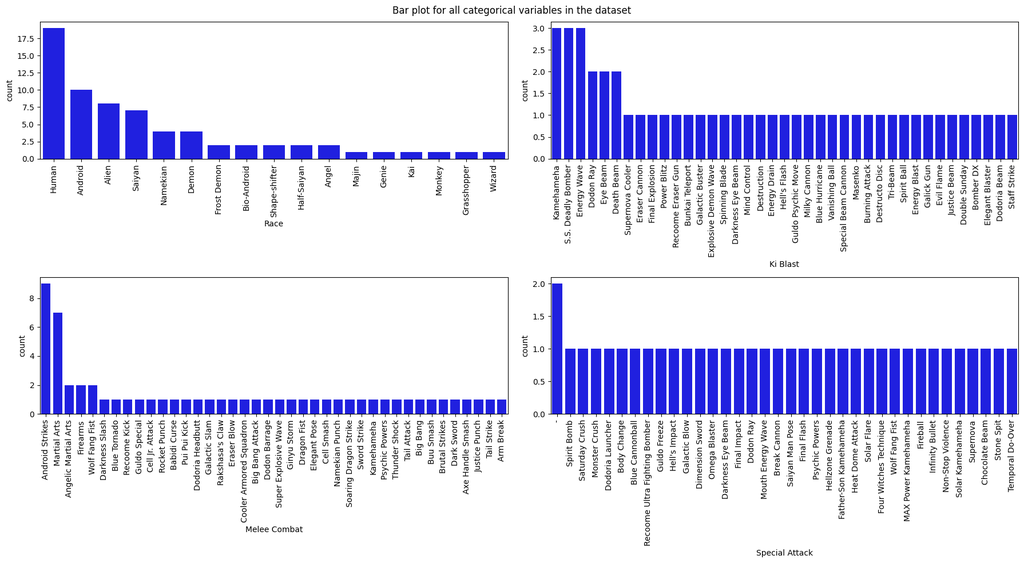

```python
fig, axes = plt.subplots(2, 2, figsize=(18, 10))

fig.suptitle('Bar plot for all categorical variables in the dataset')

sns.countplot(ax=axes[0, 0], x='Race', data=data, color='blue',
              order=data['Race'].value_counts().index)
axes[0, 0].set_xticklabels(axes[0, 0].get_xticklabels(), rotation=90)

sns.countplot(ax=axes[0, 1], x='Ki Blast', data=data, color='blue',
              order=data['Ki Blast'].value_counts().index)
axes[0, 1].set_xticklabels(axes[0, 1].get_xticklabels(), rotation=90)

sns.countplot(ax=axes[1, 0], x='Melee Combat', data=data, color='blue',
              order=data['Melee Combat'].value_counts().index)
axes[1, 0].set_xticklabels(axes[1, 0].get_xticklabels(), rotation=90)

sns.countplot(ax=axes[1, 1], x='Special Attack', data=data, color='blue',
              order=data['Special Attack'].value_counts().index)
axes[1, 1].set_xticklabels(axes[1, 1].get_xticklabels(), rotation=90)

plt.tight_layout()  # Adjust layout to fit labels
plt.show()
```

Observations

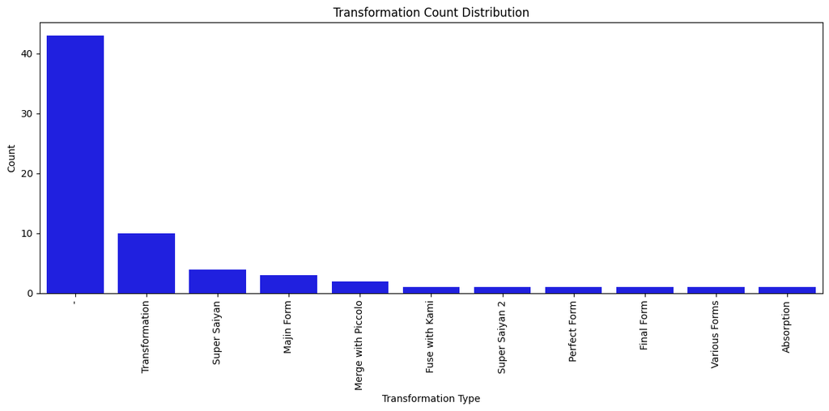

```python
plt.figure(figsize=(12, 6))  # Adjust figure size for better visibility
ax = sns.countplot(x='Transformation', data=data, color='blue',
                        order=data['Transformation'].value_counts().index)

ax.set_xticklabels(ax.get_xticklabels(), rotation=90)  # Rotate xticks

plt.title("Transformation Count Distribution")
plt.xlabel("Transformation Type")
plt.ylabel("Count")

plt.tight_layout()  # Adjust layout to prevent overlap
plt.show()
```

Observations

Insights

Histogram of Numerical Variables

```python
data.info()
```

```
<class 'pandas.core.frame.DataFrame'>
RangeIndex: 68 entries, 0 to 67
Data columns (total 9 columns):
 #   Column            Non-Null Count  Dtype
---  ------            --------------  -----
 0   Race              68 non-null     object
 1   Power Level       68 non-null     int64
 2   Ki Blast          48 non-null     object
 3   Melee Combat      57 non-null     object
 4   Speed             68 non-null     int64
 5   Special Attack    37 non-null     object
 6   Transformation    68 non-null     object
 7   Normalized_Power  68 non-null     float64
 8   Power_Score       68 non-null     float64
dtypes: float64(2), int64(2), object(5)
memory usage: 4.9+ KB
```

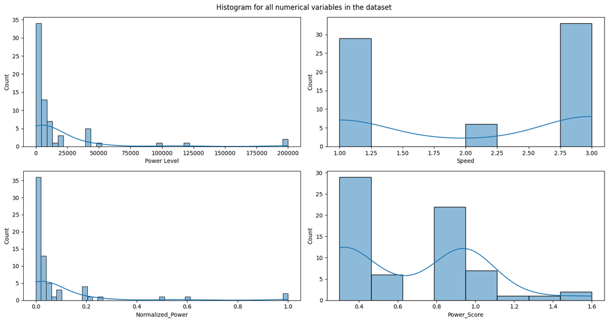

```python
fig, axes = plt.subplots(2, 2, figsize = (15, 8))

fig.suptitle('Histogram for all numerical variables in the dataset')

sns.histplot(x = 'Power Level', data = data, kde = True, ax = axes[0,0]);

sns.histplot(x = 'Speed', data = data, kde = True, ax = axes[0,1]);

sns.histplot(x = 'Normalized_Power', data = data, kde = True, ax = axes[1,0]);

sns.histplot(x = 'Power_Score', data = data, kde = True, ax = axes[1,1]);

plt.tight_layout()
```

Observations

- Power Level Distribution (Top-Left)
  - Highly right-skewed distribution: Most characters have low power levels, while only a few possess extremely high power levels.
  - A few outliers: Some characters exceed 100,000+ power levels, making them stand out significantly from the rest.
- Speed Distribution (Top-Right)
  - Three distinct speed categories: The dataset mainly contains speeds of 1, 2, and 3, suggesting a categorical-like distribution.
  - Most characters have either speed 1 or 3, while speed 2 is less common.
- Normalized Power Distribution (Bottom-Left)
  - Similar pattern to Power Level: Most characters have low normalized power, with very few reaching values near 1.0.
  - Extreme imbalance: The majority of values cluster near 0.0, suggesting that very few characters possess exceptional power.
- Power Score Distribution (Bottom-Right)
  - Bimodal distribution: There are two peaks, one around 0.4 and another around 1.0.
  - Most characters have low power scores, but there is still a subset with significantly higher values.
  - Some extreme values exist around 1.5+, indicating very powerful characters.

Insights

- Power levels and normalized power are heavily skewed, meaning most characters have relatively low power, while a few outliers dominate.
- Speed is likely categorical, as it only takes a few distinct values (1, 2, 3).
- The power score shows two peaks, indicating two broad groups of characters – weaker and stronger ones.
- Outliers exist, meaning power-related features might need transformation (e.g., log scaling) to improve modeling performance.

Correlations

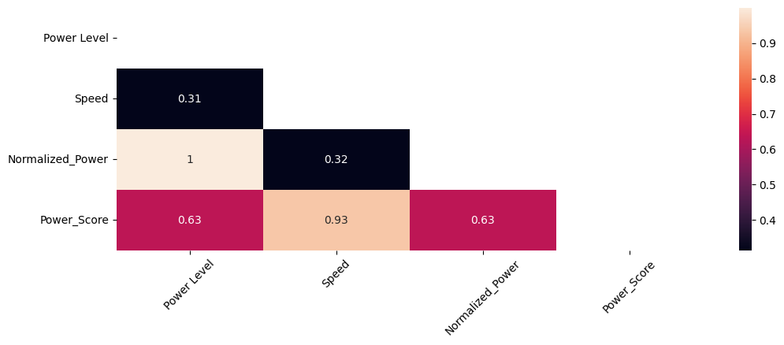

```python
fig = plt.figure(figsize = (12, 4))

mask = np.triu(data.corr(numeric_only=True))
sns.heatmap(data.corr(numeric_only=True), annot = True, mask=mask);

plt.xticks(rotation = 45);
```

Observations

Insights

- Power Level and Power Score are strongly related, meaning stronger characters tend to score higher.
- Speed is highly correlated with Power Score, suggesting fast characters are often perceived as more powerful.
- Normalized Power is an important predictor of Power Score, but other factors likely play a role too.
- Speed does not have a strong link to Power Level, meaning strength and agility are somewhat independent traits in this dataset.

Scatter plot between Independant and Dependant

```python
data.info()
```

```
<class 'pandas.core.frame.DataFrame'>
RangeIndex: 68 entries, 0 to 67
Data columns (total 9 columns):
 #   Column            Non-Null Count  Dtype
---  ------            --------------  -----
 0   Race              68 non-null     object
 1   Power Level       68 non-null     int64
 2   Ki Blast          48 non-null     object
 3   Melee Combat      57 non-null     object
 4   Speed             68 non-null     int64
 5   Special Attack    37 non-null     object
 6   Transformation    68 non-null     object
 7   Normalized_Power  68 non-null     float64
 8   Power_Score       68 non-null     float64
dtypes: float64(2), int64(2), object(5)
memory usage: 4.9+ KB
```

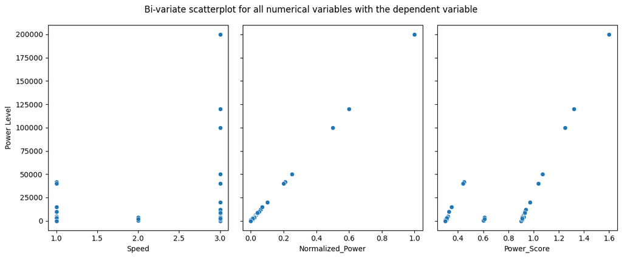

```python
fig, axes = plt.subplots(1, 3, figsize = (12, 5), sharey=True)

fig.suptitle('Bi-variate scatterplot for all numerical variables with the dependent variable')

sns.scatterplot(x = 'Speed', y = 'Power Level', data = data, ax = axes[0]);

sns.scatterplot(x = 'Normalized_Power', y = 'Power Level', data = data, ax = axes[1]);

sns.scatterplot(x = 'Power_Score', y = 'Power Level', data = data, ax = axes[2]);

plt.tight_layout()
```

Observations

- Normalized Power vs. Power Level (Middle Plot)
  - Strong positive correlation: Higher normalized power is associated with higher power levels.
  - Most data points cluster near the lower end, meaning a majority of characters have low power levels, but a few extreme cases exist.
  - A few outliers at the top suggest that some characters with high power levels also have the highest normalized power.
- Power Score vs. Power Level (Right Plot)
  - Strong positive correlation: As power level increases, power score also increases.
  - Non-linear trend: Power score increases significantly for higher power levels, indicating a possible exponential relationship.
  - This confirms Power Score is a strong predictor of Power Level

Insights

- Speed has little impact on Power Level, meaning strength does not always depend on agility.
- Normalized Power and Power Score both have strong positive correlations with Power Level, confirming their importance as predictors.
- The relationship between Power Level and Power Score appears non-linear, possibly requiring log transformation or polynomial regression for better predictions.

## Model

Select Features and Target

```python
# We are removing the outcome variable from the feature set
# Also removing the variable Power Level, as we have created a new variable Outlet_Age

train_features = data.drop(['Power Level'], axis = 1)

# And then we are extracting the outcome variable separately
train_target = data['Power Level']
```

```python
train_features.head()
```

|  | Race | Ki Blast | Melee Combat | Speed | Special Attack | Transformation | Normalized_Power | Power_Score |
| --- | --- | --- | --- | --- | --- | --- | --- | --- |
| 0 | Saiyan | Kamehameha | Dragon Fist | 3 | Spirit Bomb | Super Saiyan | 0.04 | 0.93 |
| 1 | Saiyan | Galick Gun | Big Bang | 3 | Final Flash | Super Saiyan | 0.04 | 0.93 |
| 2 | Namekian | Special Beam Cannon | Namekian Punch | 3 | Hellzone Grenade | Fuse with Kami | 0.04 | 0.93 |
| 3 | Half-Saiyan | Masenko | Soaring Dragon Strike | 3 | Father-Son Kamehameha | Super Saiyan 2 | 0.04 | 0.93 |
| 4 | Half-Saiyan | Burning Attack | Sword Strike | 3 | Heat Dome Attack | Super Saiyan | 0.04 | 0.93 |

```python
train_target.head()
```

|  | Power Level |
| --- | --- |
| 0 | 9000 |
| 1 | 8500 |
| 2 | 8000 |
| 3 | 7500 |
| 4 | 7800 |

**dtype:** int64

Categorical Variables to Convert into Dummy Variables

```python
# Creating dummy variables for the categorical variables
train_features = pd.get_dummies(train_features, drop_first = True)

train_features.head()
```

|  | Speed | Normalized_Power | Power_Score | Race_Android | Race_Angel | Race_Bio-Android | Race_Demon | Race_Frost Demon | Race_Genie | Race_Grasshopper | ... | Transformation_Absorption | Transformation_Final Form | Transformation_Fuse with Kami | Transformation_Majin Form | Transformation_Merge with Piccolo | Transformation_Perfect Form | Transformation_Super Saiyan | Transformation_Super Saiyan 2 | Transformation_Transformation | Transformation_Various Forms |
| --- | --- | --- | --- | --- | --- | --- | --- | --- | --- | --- | --- | --- | --- | --- | --- | --- | --- | --- | --- | --- | --- |
| 0 | 3 | 0.04 | 0.93 | False | False | False | False | False | False | False | ... | False | False | False | False | False | False | True | False | False | False |
| 1 | 3 | 0.04 | 0.93 | False | False | False | False | False | False | False | ... | False | False | False | False | False | False | True | False | False | False |
| 2 | 3 | 0.04 | 0.93 | False | False | False | False | False | False | False | ... | False | False | True | False | False | False | False | False | False | False |
| 3 | 3 | 0.04 | 0.93 | False | False | False | False | False | False | False | ... | False | False | False | False | False | False | False | True | False | False |
| 4 | 3 | 0.04 | 0.93 | False | False | False | False | False | False | False | ... | False | False | False | False | False | False | True | False | False | False |

5 rows × 141 columns

```python
print('We have {} features after obtaining dummy variables'.format(train_features.columns.shape[0]))
```

```
We have 141 features after obtaining dummy variables
```

## Scaling

Scaling Options

```python
from sklearn.preprocessing import (
    StandardScaler, MinMaxScaler, RobustScaler, MaxAbsScaler,
    PowerTransformer, QuantileTransformer, Normalizer
)

# 📌 Load dataset (Modify path if needed)
#file_path = "your_dataset.csv"  # Update with correct file
#data = pd.read_csv(file_path)

# 📌 Select numeric columns only
numeric_features = train_features.select_dtypes(include=['number']).dropna()

# 📌 Detect Outliers using IQR (Interquartile Range)
def detect_outliers(df):
    outlier_info = {}
    for column in df.columns:
        Q1 = df[column].quantile(0.25)
        Q3 = df[column].quantile(0.75)
        IQR = Q3 - Q1
        lower_bound = Q1 - 1.5 * IQR
        upper_bound = Q3 + 1.5 * IQR

        # Count outliers
        outlier_count = ((df[column] < lower_bound) | (df[column] > upper_bound)).sum()
        outlier_info[column] = outlier_count

    return outlier_info

outliers = detect_outliers(numeric_features)
outlier_df = pd.DataFrame.from_dict(outliers, orient='index', columns=['Outlier Count'])

# 📌 Check Skewness (to determine if transformation is needed)
skewness = numeric_features.skew()

# 📌 Scaling Options with All Variants
scalers = {
    "StandardScaler": StandardScaler(),
    "MinMaxScaler": MinMaxScaler(),
    "RobustScaler": RobustScaler(),
    "MaxAbsScaler": MaxAbsScaler(),
    "PowerTransformer (Yeo-Johnson)": PowerTransformer(method="yeo-johnson"),
    "PowerTransformer (Box-Cox)": PowerTransformer(method="box-cox"),
    "QuantileTransformer (Normal)": QuantileTransformer(output_distribution="normal"),
    "QuantileTransformer (Uniform)": QuantileTransformer(output_distribution="uniform"),
    "Normalizer (L1)": Normalizer(norm="l1"),
    "Normalizer (L2)": Normalizer(norm="l2"),
    "Normalizer (Max)": Normalizer(norm="max"),
}

scaler_results = {}

# 📌 Try all scalers & transformations
for scaler_name, scaler in scalers.items():
    try:
        transformed_data = scaler.fit_transform(numeric_features)
        transformed_df = pd.DataFrame(transformed_data, columns=numeric_features.columns, index=numeric_features.index)

        # Calculate variance after scaling (Higher is better)
        cumulative_variance = transformed_df.var().sum()
        scaler_results[scaler_name] = cumulative_variance

    except Exception as e:
        print(f"❌ Error with {scaler_name}: {e}")

# 📌 Convert results to DataFrame and Rank
scaler_rank_df = pd.DataFrame(list(scaler_results.items()), columns=['Scaler', 'Cumulative Variance'])
scaler_rank_df = scaler_rank_df.sort_values(by="Cumulative Variance", ascending=False)

# 📌 Pick the best scaler based on variance ranking
best_scaler_name = scaler_rank_df.iloc[0]["Scaler"]
best_scaler = scalers[best_scaler_name]
scaled_data = best_scaler.fit_transform(numeric_features)

# 📌 Convert Scaled Data to DataFrame
scaled_df = pd.DataFrame(scaled_data, columns=numeric_features.columns, index=numeric_features.index)

# 📌 Save the scaled dataset
scaled_df.to_csv("scaled_dataset.csv", index=False)

# 📌 Explain Selection
explanations = {
    "MinMaxScaler": "Scales data between [0,1]. Used in Unsupervised Learning & Deep Learning but NOT recommended for outliers.",
    "StandardScaler": "Standardizes data to mean=0, variance=1. Recommended for Unsupervised Learning & Deep Learning. Works well with outliers.",
    "RobustScaler": "Uses median and IQR. Best choice for handling outliers in both Unsupervised and Supervised Learning.",
    "MaxAbsScaler": "Scales data between [-1,1]. Used for sparse data, not generally needed for typical datasets.",
    "PowerTransformer (Yeo-Johnson)": "Transforms data to be more Gaussian-like. Good for skewed data in Regression & Classification.",
    "PowerTransformer (Box-Cox)": "Similar to Yeo-Johnson but works only with strictly positive values. Reduces skewness.",
    "QuantileTransformer (Normal)": "Maps data to a normal distribution. Works well when distribution is unknown.",
    "QuantileTransformer (Uniform)": "Maps data to a uniform distribution. Useful for highly irregular distributions.",
    "Normalizer (L1)": "Normalizes each row by L1 norm. Good for text-based or sparse datasets.",
    "Normalizer (L2)": "Normalizes each row by L2 norm. Often used in clustering tasks.",
    "Normalizer (Max)": "Normalizes each row by its maximum absolute value. Good for text and sparse data."
}

# 📌 Print Summary
print("\n📊 Scaler Rankings:")
print(scaler_rank_df)

print(f"\n🏆 Best Scaler Chosen: {best_scaler_name}")
print(f"📌 Reason: {explanations.get(best_scaler_name, 'No explanation available')}")

# 📌 Print Insights
if outlier_df['Outlier Count'].sum() > 0:
    print("\n⚠️ Outliers detected! **RobustScaler** is recommended if handling them is critical.")
else:
    print("\n✅ No significant outliers detected. **StandardScaler** is the default recommendation.")

if any(abs(skewness) > 1):
    print("\n⚠️ Skewed data detected! **PowerTransformer**")
```

```
❌ Error with PowerTransformer (Box-Cox): The Box-Cox transformation can only be applied to strictly positive data

📊 Scaler Rankings:
                           Scaler  Cumulative Variance
5    QuantileTransformer (Normal)            39.172363
2                    RobustScaler            20.906590
0                  StandardScaler             3.044776
4  PowerTransformer (Yeo-Johnson)             3.044776
6   QuantileTransformer (Uniform)             0.450061
1                    MinMaxScaler             0.341485
3                    MaxAbsScaler             0.188211
9                Normalizer (Max)             0.007320
8                 Normalizer (L2)             0.005507
7                 Normalizer (L1)             0.004456

🏆 Best Scaler Chosen: QuantileTransformer (Normal)
📌 Reason: Maps data to a normal distribution. Works well when distribution is unknown.

⚠️ Outliers detected! **RobustScaler** is recommended if handling them is critical.

⚠️ Skewed data detected! **PowerTransformer**
```

MinMaxScaler

- Data with a fixed range (0 to 1)
- Does not handle outliers

RobustScaler

- Data with outliers & skewed distributions
- Handles skew and outliers well

Scaling Implementation

```python
# Creating an instance of the MinMaxScaler
scaler = RobustScaler()

# Applying fit_transform on the training features data
train_features_scaled = scaler.fit_transform(train_features)

# The above scaler returns the data in array format, below we are converting it back to pandas DataFrame
train_features_scaled = pd.DataFrame(train_features_scaled, index = train_features.index, columns = train_features.columns)

train_features_scaled.sample(5)
```

|  | Speed | Normalized_Power | Power_Score | Race_Android | Race_Angel | Race_Bio-Android | Race_Demon | Race_Frost Demon | Race_Genie | Race_Grasshopper | ... | Transformation_Absorption | Transformation_Final Form | Transformation_Fuse with Kami | Transformation_Majin Form | Transformation_Merge with Piccolo | Transformation_Perfect Form | Transformation_Super Saiyan | Transformation_Super Saiyan 2 | Transformation_Transformation | Transformation_Various Forms |
| --- | --- | --- | --- | --- | --- | --- | --- | --- | --- | --- | --- | --- | --- | --- | --- | --- | --- | --- | --- | --- | --- |
| 34 | 0.5 | -0.235294 | 0.483871 | 0.0 | 0.0 | 0.0 | 0.0 | 0.0 | 0.0 | 0.0 | ... | 0.0 | 0.0 | 0.0 | 0.0 | 0.0 | 0.0 | 0.0 | 0.0 | 0.0 | 0.0 |
| 36 | 0.5 | 1.882353 | 0.580645 | 0.0 | 0.0 | 0.0 | 0.0 | 0.0 | 0.0 | 0.0 | ... | 0.0 | 0.0 | 0.0 | 0.0 | 0.0 | 0.0 | 0.0 | 0.0 | 1.0 | 0.0 |
| 30 | -0.5 | -0.470588 | -0.500000 | 0.0 | 0.0 | 0.0 | 0.0 | 0.0 | 0.0 | 1.0 | ... | 0.0 | 0.0 | 0.0 | 0.0 | 0.0 | 0.0 | 0.0 | 0.0 | 0.0 | 0.0 |
| 57 | -0.5 | 0.000000 | -0.483871 | 1.0 | 0.0 | 0.0 | 0.0 | 0.0 | 0.0 | 0.0 | ... | 0.0 | 0.0 | 0.0 | 0.0 | 0.0 | 0.0 | 0.0 | 0.0 | 0.0 | 0.0 |
| 48 | 0.5 | 0.000000 | 0.483871 | 0.0 | 0.0 | 0.0 | 0.0 | 0.0 | 0.0 | 0.0 | ... | 0.0 | 0.0 | 0.0 | 0.0 | 0.0 | 0.0 | 0.0 | 0.0 | 1.0 | 0.0 |

5 rows × 141 columns

```python
train_features_scaled_original = train_features_scaled.copy()
```

## Build the Model

Set to build the model using the statsmodels package

```python
# Importing libraries for building linear regression model
import statsmodels.api as sm # advantage of scick learn when training linear regression models: we can have summary of model regression
from statsmodels.stats.outliers_influence import variance_inflation_factor
```

```python
# Adding the intercept term
train_features_scaled = sm.add_constant(train_features_scaled)

# call the OLS algorithm on the train features and the target variable
ols_model_0 = sm.OLS(train_target, train_features_scaled)

# Fitting the model
ols_res_0 = ols_model_0.fit()

print(ols_res_0.summary())
```

```
                            OLS Regression Results
==============================================================================
Dep. Variable:            Power Level   R-squared:                       1.000
Model:                            OLS   Adj. R-squared:                  1.000
Method:                 Least Squares   F-statistic:                 3.415e+05
Date:                Fri, 28 Feb 2025   Prob (F-statistic):           2.71e-24
Time:                        03:00:40   Log-Likelihood:                -317.06
No. Observations:                  68   AIC:                             752.1
Df Residuals:                       9   BIC:                             883.1
Df Model:                          58
Covariance Type:            nonrobust
================================================================================================================
                                                   coef    std err          t      P>|t|      [0.025      0.975]
----------------------------------------------------------------------------------------------------------------
const                                         4785.8185    457.016     10.472      0.000    3751.976    5819.661
Speed                                         9.014e+04   6.04e+04      1.491      0.170   -4.66e+04    2.27e+05
Normalized_Power                              1.275e+04   2994.160      4.258      0.002    5976.741    1.95e+04
Power_Score                                    -9.3e+04   6.25e+04     -1.489      0.171   -2.34e+05    4.83e+04
Race_Android                                    84.2530     81.432      1.035      0.328     -99.958     268.464
Race_Angel                                    1741.3475    177.003      9.838      0.000    1340.939    2141.756
Race_Bio-Android                              -383.4194    230.719     -1.662      0.131    -905.342     138.503
Race_Demon                                     192.2319     92.769      2.072      0.068     -17.627     402.091
Race_Frost Demon                               -62.7929    115.713     -0.543      0.601    -324.553     198.967
Race_Genie                                     709.0344    107.131      6.618      0.000     466.688     951.381
Race_Grasshopper                              -210.2303     93.759     -2.242      0.052    -422.328       1.867
Race_Half-Saiyan                              -152.9814     60.116     -2.545      0.031    -288.973     -16.990
Race_Human                                    -207.7303     78.906     -2.633      0.027    -386.229     -29.231
Race_Kai                                      1784.7697    556.300      3.208      0.011     526.332    3043.208
Race_Majin                                     256.9539     18.294     14.046      0.000     215.570     298.338
Race_Monkey                                   -115.2303     93.759     -1.229      0.250    -327.328      96.867
Race_Namekian                                  284.7697    259.439      1.098      0.301    -302.123     871.663
Race_Saiyan                                    453.8916    109.023      4.163      0.002     207.264     700.519
Race_Shape-shifter                            -207.7303     81.896     -2.537      0.032    -392.992     -22.469
Race_Wizard                                     94.9232     86.820      1.093      0.303    -101.477     291.324
Ki Blast_Bomber DX                            -413.2367    187.675     -2.202      0.055    -837.787      11.313
Ki Blast_Bunkai Teleport                      -131.4810     22.645     -5.806      0.000    -182.706     -80.256
Ki Blast_Burning Attack                       -102.1251     36.143     -2.826      0.020    -183.886     -20.364
Ki Blast_Darkness Eye Beam                     -16.2129     31.883     -0.509      0.623     -88.336      55.911
Ki Blast_Death Beam                           -244.6537    122.360     -1.999      0.077    -521.452      32.145
Ki Blast_Destruction                          1160.8983    123.673      9.387      0.000     881.131    1440.665
```

[output cut: 113 more lines]

```
Transformation_Super Saiyan 2                  -50.8563     30.279     -1.680      0.127    -119.352      17.639
Transformation_Transformation                  345.8045    128.060      2.700      0.024      56.114     635.495
Transformation_Various Forms                   256.9539     18.294     14.046      0.000     215.570     298.338
==============================================================================
Omnibus:                       62.795   Durbin-Watson:                   2.370
Prob(Omnibus):                  0.000   Jarque-Bera (JB):              784.565
Skew:                           2.278   Prob(JB):                    4.30e-171
Kurtosis:                      19.004   Cond. No.                     3.82e+17
==============================================================================

Notes:
[1] Standard Errors assume that the covariance matrix of the errors is correctly specified.
[2] The input rank is higher than the number of observations.
[3] The smallest eigenvalue is 1.06e-32. This might indicate that there are
strong multicollinearity problems or that the design matrix is singular.
```

- F-statistic: Lets you compare models in their ability to "explain" the variance in the dependent variable. More information here.
- Log-likelihood. Measure the goodness of fit for a model. The higher the value of the log-likelihood, the better a model fits a dataset.
- AIC and BIC are methods to compare models and determine which one is the best fit for the data.
  - Akaike Information Criterion (AIC): It uses the maximum likelihood and the number of independent variables in the model. Simply choose the model giving smallest AIC. More information here.
  - Bayesian Information Criterion (BIC): Unlike the AIC, the BIC penalizes the model more for its complexity, meaning that more complex models will have a worse (larger) score and will, in turn, be less likely to be selected. More information here.
- Omnibus/Prob(Omnibus): The Prob (Omnibus) performs a statistical test indicating the probability that the residuals are normally distributed.
- Skew: A measure of data symmetry. We want to see something close to zero, indicating the residual distribution is normal.
- Kurtosis: A measure of "peakiness", or curvature of the data.
- Durbin-Watson: Tests for homoscedasticity. We hope to have a value between 1 and 2.
- Jarque-Bera (JB)/Prob(JB): Like the Omnibus test in that it tests both skew and kurtosis.
- Condition Number: This test measures the sensitivity of a function's output as compared to its input. If the value is greater to 30, we have multicollinearity.

Observations

- Multicollinearity Issue
  - The design matrix is singular (Cond. No. = 3.82e+17).
  - This means some features are highly correlated, making coefficients unreliable.
  - Fix: Use VIF analysis & drop highly correlated features.
- Overfitting Risk
  - R² = 1.000 and Adjusted R² = 1.000 → The model perfectly fits the data.
  - Fix: Reduce features, apply regularization (Ridge/Lasso), or get more data.
- Key Feature Importance
  - Strong Positive Influence on Power Level:
    - Transformations (Super Saiyan, Various Forms)
    - Angel Race
    - Certain Ki Blasts & Melee Attacks (e.g., Kamehameha, Vanishing Ball, Supernova).
  - Negative Influence on Power Level:
    - Lower-tier races (Monkey, Frost Demon)
    - Weaker attacks (e.g., Darkness Slash, Burning Attack, Dodon Ray).
- Feature Significance (p-values)
  - Some features are not statistically significant (p > 0.05).
  - Example: Speed, certain Ki Blasts & Melee Attacks are not strongly influencing power levels.
  - Fix: Drop non-significant features to improve model interpretability.
- Model Assumptions Check
  - High Skewness (2.278) & Kurtosis (19.004) → The distribution is not normal.
  - Fix: Consider Power Transformations (Box-Cox/Yeo-Johnson) to stabilize variance.

Suggestions:

- P-value > 0.05: Drop feature general standard is 0.05 (95% confidence interval)
- Fix: Use VIF analysis & drop highly correlated features.
- Reduce features, apply regularization (Ridge/Lasso), or get more data.
- Drop non-significant features to improve model interpretability.
- Fix: Consider Power Transformations (Box-Cox/Yeo-Johnson) to stabilize variance.

## Feature Selection

- Checking for the assumptions and rebuilding the model
- check whether the below assumptions hold true or not for the model, fix issue, and rebilt model
1. Mean of residuals should be 0
2. Normality of error terms
3. Linearity of variables
4. No heteroscedasticity

### Removing Multicollinearity

- Multicollinearity occurs when predictor variables in a regression model are correlated. This correlation is a problem because predictor variables should be independent. If the correlation between independent variables is high, it can cause problems when we fit the model and interpret the results. When we have multicollinearity in the linear model, the coefficients that the model suggests are unreliable.
  - Correlation measures the strength and direction of the relationship between two variables.
  - The correlation coefficient, denoted as r, ranges from -1 to 1.
- r ≈ 1:
  - This indicates a strong positive correlation, meaning as one variable increases, the other also increases in a very predictable way
- r ≈ −1:
  - This indicates a strong negative correlation, meaning as one variable increases, the other decreases in a very predictable way.
- There are different ways of detecting (or testing) multicollinearity. One such way is the Variation Inflation Factor (VIF) or pearson correlation coefficient
- Variance Inflation factor: Variance inflation factor measures the inflation in the variances of the regression parameter estimates due to collinearities that exist among the predictors. It is a measure of how much the variance of the estimated regression coefficient βk is “inflated” by the existence of correlation among the predictor variables in the model.
- General Rule of thumb: If VIF is 1, then there is no correlation between the kth predictor and the remaining predictor variables, and hence the variance of β̂k is not inflated at all. Whereas, if VIF exceeds 5 or is close to exceeding 5, we say there is moderate VIF and if it is 10 or exceeds 10, it shows signs of high multicollinearity.

General Rule of thumb:

- If VIF is 1, then there is no correlation between the kth predictor and the remaining predictor variables,
- and hence the variance of β̂k is not inflated at all. Whereas, if VIF exceeds 5 or is close to exceeding 5, we say there is moderate VIF
- and if it is 10 or exceeds 10, it shows signs of high multicollinearity.

Define Function to Remove High P-Values and High VIF

Original Model: ols_res_0

```python
from statsmodels.stats.outliers_influence import variance_inflation_factor
import statsmodels.api as sm

def remove_high_pvalues_vif(feature_data, target_data, pvalue_threshold=0.05, vif_threshold=10):
    """
    Iteratively removes features with high p-values and high VIF.

    Parameters:
    - feature_data: DataFrame containing features used in the model.
    - target_data: Series or array containing the target variable.
    - pvalue_threshold: The threshold for p-values to retain a feature (default = 0.05).
    - vif_threshold: The threshold for Variance Inflation Factor (default = 10).

    Returns:
    - final_features: List of remaining features after filtering.
    - removed_pvalues: List of removed features due to high p-values.
    - removed_vif: List of removed features due to high VIF.
    """

    # Ensure consistent index alignment
    feature_data = feature_data.reset_index(drop=True)
    target_data = target_data.reset_index(drop=True)

    # Start with all features
    remaining_features = feature_data.columns.tolist()
    removed_pvalues, removed_vif = [], []

    iteration = 1

    while True:
        print(f"\n🔄 **Iteration {iteration}: Running P-Value and VIF Analysis**")

        # Fit OLS model
        X = sm.add_constant(feature_data[remaining_features])
        model = sm.OLS(target_data, X).fit()

        # Extract and format p-values
        pvalues = model.pvalues[1:].apply(lambda x: round(x, 2))  # Format as xx.xx

        # Compute VIF values
        vif_values = pd.Series(
            [variance_inflation_factor(X[remaining_features].values, i) for i in range(len(remaining_features))],
            index=remaining_features
        )

        # Display results
        results_table = pd.DataFrame({"Feature": remaining_features, "P-Value": pvalues, "VIF": vif_values})
        print(results_table)

        # Identify max p-value and max VIF
        max_pvalue = pvalues.max()
        max_vif = vif_values.max()

        if max_pvalue < pvalue_threshold and max_vif < vif_threshold:
            print("\n✅ **All Features Meet Criteria! Stopping Iterations.**")
            break  # Stop if all conditions are met

        # Remove highest p-value if above threshold
        if max_pvalue >= pvalue_threshold:
            feature_to_remove = pvalues.idxmax()
            print(f"\n🚨 **Removing Feature (High P-Value):** {feature_to_remove} | P-Value: {max_pvalue:.2f}")
            remaining_features.remove(feature_to_remove)
            removed_pvalues.append(feature_to_remove)

        # Remove highest VIF if above threshold
        elif max_vif >= vif_threshold:
            feature_to_remove = vif_values.idxmax()
            print(f"\n🚨 **Removing Feature (High VIF):** {feature_to_remove} | VIF: {max_vif:.2f}")
            remaining_features.remove(feature_to_remove)
            removed_vif.append(feature_to_remove)

        iteration += 1

    return remaining_features, removed_pvalues, removed_vif
```

```python
# Ensure data consistency
train_features_scaled_new = train_features_scaled_new.copy().reset_index(drop=True)
train_target = train_target.reset_index(drop=True)

# Run feature selection
remaining_features, removed_pvalues, removed_vif = remove_high_pvalues_vif(
    train_features_scaled_new, train_target, pvalue_threshold=0.05, vif_threshold=10
)

# Display final feature selection results
print("\n✅ **Final Remaining Features After P-Value & VIF Filtering:**")
print(remaining_features)

print("\n🚫 **Removed Due to High P-Value:**")
print(removed_pvalues)

print("\n🚫 **Removed Due to High VIF:**")
print(removed_vif)
```

[output not shown]

[output not shown]

[output cut: 4946 more lines]

```
Transformation_Merge with Piccolo  1.009412
Transformation_Super Saiyan        1.330196
Transformation_Transformation      1.118301
const                              1.360000

✅ **All Features Meet Criteria! Stopping Iterations.**

✅ **Final Remaining Features After P-Value & VIF Filtering:**
['const', 'Melee Combat_Angelic Martial Arts', 'Special Attack_Body Change', 'Special Attack_Heat Dome Attack', 'Transformation_Merge with Piccolo', 'Transformation_Super Saiyan', 'Transformation_Transformation']

🚫 **Removed Due to High P-Value:**
['Melee Combat_Thunder Shock', 'Special Attack_MAX Power Kamehameha', 'Ki Blast_Kamehameha', 'Ki Blast_Spirit Ball', 'Special Attack_Wolf Fang Fist', 'Ki Blast_Darkness Eye Beam', 'Melee Combat_Darkness Slash', 'Transformation_Absorption', 'Ki Blast_S.S. Deadly Bomber', 'Melee Combat_Tail Attack', '…

🚫 **Removed Due to High VIF:**
['Race_Angel', 'Race_Bio-Android', 'Race_Majin', 'Race_Saiyan', 'Race_Wizard', 'Ki Blast_Bomber DX', 'Ki Blast_Bunkai Teleport', 'Ki Blast_Burning Attack', 'Ki Blast_Destruction', 'Ki Blast_Destructo Disc', 'Ki Blast_Dodon Ray', 'Ki Blast_Energy Wave', 'Ki Blast_Eraser Cannon', 'Ki Blast_Evil Flame'…
```

Create Final Model Using Updated Features

```python
# Fit final model using refined features
X_final = sm.add_constant(train_features_scaled_new[remaining_features])
final_model = sm.OLS(train_target, X_final).fit()

# Display final model summary
print("\n⭐ **Final Model Summary:**")
print(final_model.summary())
```

```
⭐ **Final Model Summary:**
                            OLS Regression Results
==============================================================================
Dep. Variable:            Power Level   R-squared:                       0.910
Model:                            OLS   Adj. R-squared:                  0.901
Method:                 Least Squares   F-statistic:                     102.5
Date:                Fri, 28 Feb 2025   Prob (F-statistic):           5.87e-30
Time:                        03:01:29   Log-Likelihood:                -731.83
No. Observations:                  68   AIC:                             1478.
Df Residuals:                      61   BIC:                             1493.
Df Model:                           6
Covariance Type:            nonrobust
=====================================================================================================
                                        coef    std err          t      P>|t|      [0.025      0.975]
-----------------------------------------------------------------------------------------------------
const                              3872.4000   1705.542      2.270      0.027     461.957    7282.843
Melee Combat_Angelic Martial Arts  1.961e+05   8696.594     22.552      0.000    1.79e+05    2.14e+05
Special Attack_Body Change         8.956e+04   1.27e+04      7.045      0.000    6.41e+04    1.15e+05
Special Attack_Heat Dome Attack   -3.137e+04   1.39e+04     -2.252      0.028   -5.92e+04   -3520.518
Transformation_Merge with Piccolo  1.863e+04   8696.594      2.142      0.036    1237.686     3.6e+04
Transformation_Super Saiyan        3.529e+04   7168.690      4.923      0.000     2.1e+04    4.96e+04
Transformation_Transformation      2.657e+04   4366.840      6.085      0.000    1.78e+04    3.53e+04
==============================================================================
Omnibus:                       46.089   Durbin-Watson:                   1.471
Prob(Omnibus):                  0.000   Jarque-Bera (JB):              383.584
Skew:                           1.583   Prob(JB):                     5.08e-84
Kurtosis:                      14.196   Cond. No.                         10.0
==============================================================================

Notes:
[1] Standard Errors assume that the covariance matrix of the errors is correctly specified.
```

Validate Final Model P-Values and VIF

```python
# Extract final p-values (excluding intercept)
final_pvalues = final_model.pvalues[1:].apply(lambda x: round(x, 2))

# Compute final VIF values
final_vif_values = pd.Series(
    [variance_inflation_factor(X_final[remaining_features].values, i) for i in range(len(remaining_features))],
    index=remaining_features
)

# Display validation results
print("\n🔎 **Final Validation Check:**")
validation_table = pd.DataFrame({"Feature": remaining_features, "P-Value": final_pvalues, "VIF": final_vif_values})
print(validation_table)

# Check optimization status
if (final_pvalues > 0.05).sum() == 0 and all(vif < 10 for vif in final_vif_values):
    print("\n✅ **Final Model is Optimized: All Features Have P-Values < 0.05 & VIF < 10. Ready for Use!**")
else:
    print("\n⚠️ **Some issues still exist. Consider further refinement.**")
```

```
🔎 **Final Validation Check:**
                                                             Feature  P-Value  \
Melee Combat_Angelic Martial Arts                              const     0.00
Special Attack_Body Change         Melee Combat_Angelic Martial Arts     0.00
Special Attack_Heat Dome Attack           Special Attack_Body Change     0.03
Transformation_Merge with Piccolo    Special Attack_Heat Dome Attack     0.04
Transformation_Super Saiyan        Transformation_Merge with Piccolo     0.00
Transformation_Transformation            Transformation_Super Saiyan     0.00
const                                  Transformation_Transformation      NaN

                                        VIF
Melee Combat_Angelic Martial Arts  1.009412
Special Attack_Body Change         1.094771
Special Attack_Heat Dome Attack    1.313725
Transformation_Merge with Piccolo  1.009412
Transformation_Super Saiyan        1.330196
Transformation_Transformation      1.118301
const                              1.360000

✅ **Final Model is Optimized: All Features Have P-Values < 0.05 & VIF < 10. Ready for Use!**
```

```python
# train_features_scaled.columns.to_list()
```

```python
# train_features_scaled_new.columns.to_list()
```

Updated ols_res_0 to **final_model**

Updated train_features_scaled to **train_features_scaled_new**

```python
final_model
```

```
<statsmodels.regression.linear_model.RegressionResultsWrapper at 0x78ec98c37cd0>
```

### Mean of residuals should be 0

```python
# Residuals Calculation
# Use the most recent model (new_model_after_vif_analysis)
residual = final_model.resid

# Calculate the mean of residuals
residual_mean = residual.mean()
print(f"Mean of Residuals: {residual_mean}")

# Interpretation
if abs(residual_mean) < 1e-10:  # Adjust the tolerance as needed
    print("\nThe mean of residuals is very close to 0. Hence, the corresponding assumption is satisfied.")
else:
    print("\nThe mean of residuals is not close to 0. The assumption may not be satisfied.")
```

```
Mean of Residuals: 1.669190276195021e-11

The mean of residuals is very close to 0. Hence, the corresponding assumption is satisfied.
```

### Tests for Normality

- Error terms/Residuals should be normally distributed.
- If the error terms are non-normally distributed, confidence intervals may become too wide or narrow. Once the confidence interval becomes unstable, it leads to difficulty in estimating coefficients based on the minimization of least squares.
- It suggests that there are a few unusual data points that must be studied closely to make a better model.

How to check the normality

- We can plot the histogram of residuals and check the distribution visually.
- It can be checked via QQ Plot. Residuals following normal distribution will make a straight line plot otherwise not.
- Another test to check for normality: The Shapiro-Wilk test.

Fix

- apply transformations like log, exponential, arcsinh, etc. as per our data

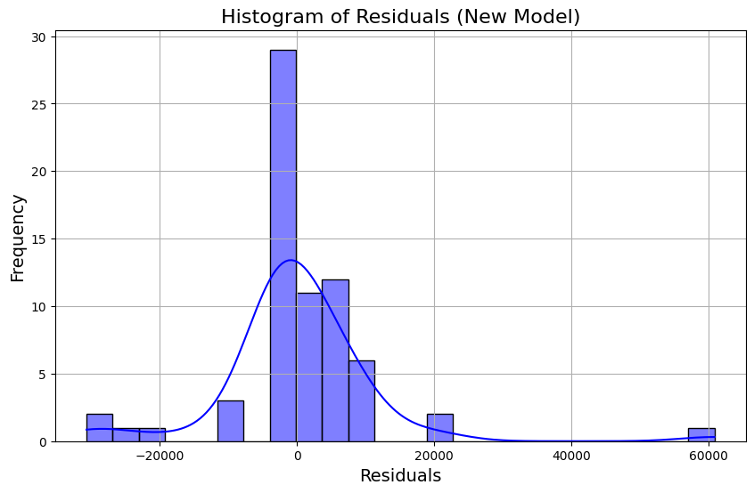

```python
# Plot histogram of residuals with KDE (Kernel Density Estimate)
plt.figure(figsize=(10, 6))
sns.histplot(residual, kde=True, color="blue")
plt.title("Histogram of Residuals (New Model)", fontsize=16)
plt.xlabel("Residuals", fontsize=14)
plt.ylabel("Frequency", fontsize=14)
plt.grid(True)
plt.show()
```

Residual Distribution:

- The histogram shows that most residuals are clustered around zero, which is ideal.
- The kernel density estimate (KDE) line suggests a somewhat normal distribution, but there are visible deviations.

Outliers & Skewness:

- There are a few extreme residuals on both the negative and positive sides, indicating possible outliers.
- The right tail (positive residuals) extends further, suggesting a potential right-skewed distribution.

### Linearity of Variables

- states that the predictor variables must have a linear relation with the dependent variable
- plot the residuals and the fitted values and ensure that residuals do not form a strong pattern. They should be randomly and uniformly scattered on the x-axis

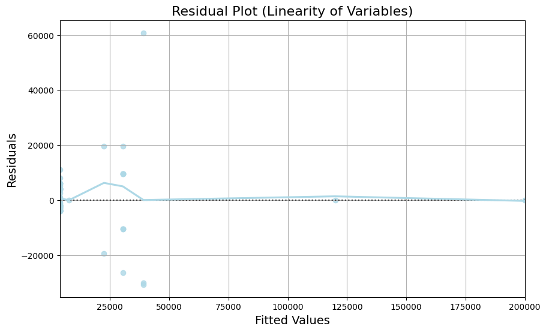

```python
# Predicted (fitted) values and residuals from the newest model
fitted = final_model.fittedvalues

# Residual plot
plt.figure(figsize=(10, 6))
sns.residplot(x=fitted, y=residual, color="lightblue", lowess=True)
plt.xlabel("Fitted Values", fontsize=14)
plt.ylabel("Residuals", fontsize=14)
plt.title("Residual Plot (Linearity of Variables)", fontsize=16)
plt.grid(True)
plt.show()
```

- Linearity Check:
  - Ideally, residuals should be randomly scattered around zero with no clear pattern.
  - The residuals mostly hover around zero, but there are some deviations, especially at lower fitted values.
- Outliers & Influential Points:
  - Several large residuals (positive and negative) indicate potential outliers.
  - These could bias model predictions and should be further examined using Cook’s Distance or Leverage Plots.
- Lowess (Locally Weighted Regression) Curve:
  - The blue Lowess curve slightly deviates from zero in the lower fitted values.
  - This suggests a possible non-linearity in the data that the model isn’t capturing well.

Implement Fix

- apply the log transformation on the target variable and try to build a new model.

```python
# Log transformation on the target variable for the new model
train_target_log = np.log(train_target)

# Fitting new model with the transformed target variable
final_model = sm.OLS(train_target_log, train_features_scaled_new)

final_model = final_model.fit()
```

```python
# Fitting new model with the transformed target variable
final_model = sm.OLS(train_target_log, train_features_scaled_new)

final_model = final_model.fit()
```

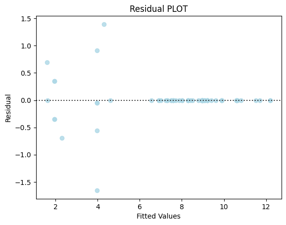

```python
# Predicted values
fitted = final_model.fittedvalues

residual1 = final_model.resid

sns.residplot(x = fitted, y = residual1, color = "lightblue")

plt.xlabel("Fitted Values")

plt.ylabel("Residual")

plt.title("Residual PLOT")

plt.show()
```

- Log Transformation Applied:
  - The target variable (train_target) was transformed using the natural logarithm (np.log(train_target)).
  - This transformation helps to stabilize variance, make relationships more linear, and improve model performance.
- Fitting the Log-Transformed Model:
  - The model (final_model) was trained using the transformed target (train_target_log).
  - This approach often improves regression assumptions like normality and homoscedasticity of residuals.
- Residual Plot Analysis:
  - The residuals are centered around zero, which is a good sign.
  - However, there are a few outliers with larger residuals.
  - Most residuals are tightly clustered near zero, indicating the model captures the majority of variation well.

```python
# print(final_model.summary())
```

### No Heteroscedasticity

Test for Homoscedasticity

- Homoscedasticity - If the variance of the residuals are symmetrically distributed across the regression line, then the data is said to homoscedastic.
- Heteroscedasticity - If the variance is unequal for the residuals across the regression line, then the data is said to be heteroscedastic. In this case, the residuals can form an arrow shape or any other non symmetrical shape.
- We will use Goldfeld–Quandt test to check homoscedasticity.
  - Null hypothesis : Residuals are homoscedastic
  - Alternate hypothesis : Residuals are hetroscedastic

```python
import statsmodels.stats.api as sms
from statsmodels.compat import lzip

name = ["F statistic", "p-value"]

test = sms.het_goldfeldquandt(train_target_log, train_features_scaled_new)

lzip(name, test)
```

```
[('F statistic', 0.6564517451301212), ('p-value', 0.5668343085677284)]
```

- Test Explanation:
  - The Goldfeld-Quandt test checks for heteroscedasticity (unequal variance in residuals).
  - Null hypothesis (H₀): Residuals are homoscedastic (equal variance).
  - Alternative hypothesis (H₁): Residuals are heteroscedastic (unequal variance).
- Results Interpretation:
  - F-statistic = 0.6564 (lower values generally suggest homoscedasticity).
  - P-value = 0.5668 (greater than 0.05, meaning we fail to reject the null hypothesis).
  - Since p > 0.05, the test does not provide evidence of heteroscedasticity.
- Conclusion:
  - The residual variance appears uniformly distributed across fitted values.
  - The assumption of homoscedasticity is satisfied, which supports the validity of regression estimates.

## Evaluation Metrics

R-Squared

- The R-squared metric gives us an indication that how good/bad our model is from a baseline model

```python
print(final_model.rsquared)
```

```
0.985862004163971
```

Mean Squared Error

- This metric measures the average of the squares of the errors, i.e., the average squared difference between the estimated values and the actual value.

```python
print(final_model.mse_resid)
```

```
0.808999699008203
```

Root Mean Squared Error

- This metric is the same as the above but, instead of simply taking the average, we also take the square root of MSE to get RMSE.
- This helps to get the metric in the same unit as the target variable.

```python
print(np.sqrt(final_model.mse_resid))
```

```
0.8994441055497573
```

Checking the cross-validation score to identify if the model that we have built is underfitted, overfitted or just right fit model.

```python
# Fitting linear model

from sklearn.linear_model import LinearRegression
from sklearn.model_selection import cross_val_score

linearregression = LinearRegression()

cv_Score11 = cross_val_score(linearregression, train_features_scaled_new, train_target_log, cv = 10) # 10 is fold iterations

cv_Score12 = cross_val_score(linearregression, train_features_scaled_new, train_target_log, cv = 10,
                             scoring = 'neg_mean_squared_error')

print("RSquared: %0.3f (+/- %0.3f)" % (cv_Score11.mean(), cv_Score11.std()*2))

print("Mean Squared Error: %0.3f (+/- %0.3f)" % (-1*cv_Score12.mean(), cv_Score12.std()*2))
```

```
RSquared: -5.031 (+/- 20.480)
Mean Squared Error: 9.245 (+/- 17.415)
```

Observations

## Predictions on the Test Dataset

```python
test_df = train_features_scaled_new.sample(frac=0.2, random_state=42)  # 20% sample of training data
```

```python
# Reinitialize and fit the scaler on training data if it's missing
robust_scaler = RobustScaler()
robust_scaler.fit(train_features_scaled)  # Fit using training data
```

```
RobustScaler()
```

```python
print("Test feature order:\n", test_features_scaled.columns.tolist())
print("Train feature order:\n", train_features_scaled_new.columns.tolist())
```

[output not shown]

```python
missing_columns = list(set(train_features_scaled_new.columns) - set(test_features_scaled.columns))
extra_columns = list(set(test_features_scaled.columns) - set(train_features_scaled_new.columns))

print("Missing columns in test data:\n", missing_columns)
print("Extra columns in test data:\n", extra_columns)
```

[output not shown]

```python
for col in missing_columns:
    test_features_scaled[col] = 0  # Add missing columns with default value 0
```

```python
# Ensure test features match training feature structure
train_features_columns = train_features_scaled.columns.tolist()

# Select corresponding columns in test data (excluding target variable)
test_features = test_df[train_features_columns[1:]]  # Exclude 'const' if applicable

# Apply the same RobustScaler used for training
test_features_scaled = scaler.transform(test_features)

# Convert scaled array back to DataFrame
test_features_scaled = pd.DataFrame(test_features_scaled, columns=test_features.columns)

# Add constant column back (as was done for training data)
test_features_scaled = sm.add_constant(test_features_scaled)

# Debugging: Check column alignment
print("Final test feature columns:\n", test_features_scaled.columns)


# # Drop columns
# test_features_scaled = test_features_scaled.drop([''], axis = 1) # my removed features
```

```
Final test feature columns:
 Index(['const', 'Speed', 'Normalized_Power', 'Power_Score', 'Race_Android',
       'Race_Angel', 'Race_Bio-Android', 'Race_Demon', 'Race_Frost Demon',
       'Race_Genie',
       ...
       'Transformation_Absorption', 'Transformation_Final Form',
       'Transformation_Fuse with Kami', 'Transformation_Majin Form',
       'Transformation_Merge with Piccolo', 'Transformation_Perfect Form',
       'Transformation_Super Saiyan', 'Transformation_Super Saiyan 2',
       'Transformation_Transformation', 'Transformation_Various Forms'],
      dtype='object', length=142)
```

```python
# test_features_scaled.columns.to_list()
```

```python
# train_features_scaled.columns.to_list()
```

```python
test_features_scaled.head()
```

|  | const | Speed | Normalized_Power | Power_Score | Race_Android | Race_Angel | Race_Bio-Android | Race_Demon | Race_Frost Demon | Race_Genie | ... | Transformation_Absorption | Transformation_Final Form | Transformation_Fuse with Kami | Transformation_Majin Form | Transformation_Merge with Piccolo | Transformation_Perfect Form | Transformation_Super Saiyan | Transformation_Super Saiyan 2 | Transformation_Transformation | Transformation_Various Forms |
| --- | --- | --- | --- | --- | --- | --- | --- | --- | --- | --- | --- | --- | --- | --- | --- | --- | --- | --- | --- | --- | --- |
| 0 | 1.0 | -1.25 | -6.006920 | -1.764308 | 0.0 | 0.0 | 0.0 | 0.0 | 0.0 | 0.0 | ... | 0.0 | 0.0 | 0.0 | 0.0 | 0.0 | 0.0 | 0.0 | 0.0 | 0.0 | 0.0 |
| 1 | 1.0 | -1.25 | -11.543253 | -1.790323 | 0.0 | 0.0 | 0.0 | 0.0 | 0.0 | 0.0 | ... | 0.0 | 0.0 | 0.0 | 0.0 | 0.0 | 0.0 | 0.0 | 0.0 | 0.0 | 0.0 |
| 2 | 1.0 | -0.75 | 10.602076 | -0.151405 | 0.0 | 0.0 | 0.0 | 0.0 | 0.0 | 0.0 | ... | 0.0 | 0.0 | 0.0 | 0.0 | 0.0 | 0.0 | 1.0 | 0.0 | 0.0 | 0.0 |
| 3 | 1.0 | -1.25 | -11.543253 | -1.790323 | 0.0 | 0.0 | 0.0 | 0.0 | 0.0 | 0.0 | ... | 0.0 | 0.0 | 0.0 | 0.0 | 0.0 | 0.0 | 0.0 | 0.0 | 0.0 | 0.0 |
| 4 | 1.0 | -1.25 | -0.470588 | -1.738293 | 0.0 | 0.0 | 0.0 | 0.0 | 0.0 | 0.0 | ... | 0.0 | 0.0 | 0.0 | 0.0 | 0.0 | 0.0 | 0.0 | 0.0 | 0.0 | 0.0 |

5 rows × 142 columns

```python
# Print final test features for verification
train_features_scaled_new.head()
```

|  | const | Speed | Normalized_Power | Power_Score | Race_Android | Race_Angel | Race_Bio-Android | Race_Demon | Race_Frost Demon | Race_Genie | ... | Transformation_Absorption | Transformation_Final Form | Transformation_Fuse with Kami | Transformation_Majin Form | Transformation_Merge with Piccolo | Transformation_Perfect Form | Transformation_Super Saiyan | Transformation_Super Saiyan 2 | Transformation_Transformation | Transformation_Various Forms |
| --- | --- | --- | --- | --- | --- | --- | --- | --- | --- | --- | --- | --- | --- | --- | --- | --- | --- | --- | --- | --- | --- |
| 0 | 1.0 | 0.5 | 0.470588 | 0.516129 | 0.0 | 0.0 | 0.0 | 0.0 | 0.0 | 0.0 | ... | 0.0 | 0.0 | 0.0 | 0.0 | 0.0 | 0.0 | 1.0 | 0.0 | 0.0 | 0.0 |
| 1 | 1.0 | 0.5 | 0.470588 | 0.516129 | 0.0 | 0.0 | 0.0 | 0.0 | 0.0 | 0.0 | ... | 0.0 | 0.0 | 0.0 | 0.0 | 0.0 | 0.0 | 1.0 | 0.0 | 0.0 | 0.0 |
| 2 | 1.0 | 0.5 | 0.470588 | 0.516129 | 0.0 | 0.0 | 0.0 | 0.0 | 0.0 | 0.0 | ... | 0.0 | 0.0 | 1.0 | 0.0 | 0.0 | 0.0 | 0.0 | 0.0 | 0.0 | 0.0 |
| 3 | 1.0 | 0.5 | 0.470588 | 0.516129 | 0.0 | 0.0 | 0.0 | 0.0 | 0.0 | 0.0 | ... | 0.0 | 0.0 | 0.0 | 0.0 | 0.0 | 0.0 | 0.0 | 1.0 | 0.0 | 0.0 |
| 4 | 1.0 | 0.5 | 0.470588 | 0.516129 | 0.0 | 0.0 | 0.0 | 0.0 | 0.0 | 0.0 | ... | 0.0 | 0.0 | 0.0 | 0.0 | 0.0 | 0.0 | 1.0 | 0.0 | 0.0 | 0.0 |

5 rows × 142 columns

Get predictions

```python
# These test predictions will be on a log scale
test_predictions = final_model.predict(test_features_scaled)

# We are converting the log scale predictions to its original scale
test_predictions_inverse_transformed = np.exp(test_predictions) # important
#test_predictions_inverse_transformed = np.exp(test_predictions) - 1


test_predictions_inverse_transformed
```

[output not shown]

**dtype:** float64

```python
test_predictions_clipped = np.clip(test_predictions, a_min=None, a_max=10)
test_predictions_inverse_transformed = np.exp(test_predictions_clipped)
```

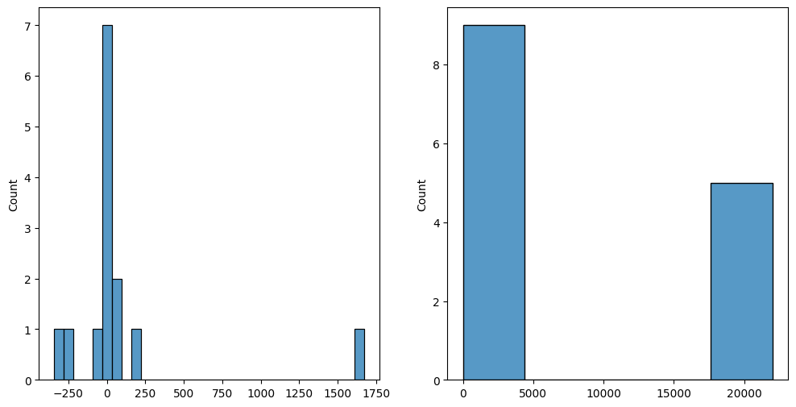

```python
fig, ax = plt.subplots(1, 2, figsize = (12, 6))

sns.histplot(test_predictions, ax = ax[0]);

sns.histplot(test_predictions_inverse_transformed, ax = ax[1]);
```

Observations

- Left Plot (Test Predictions - Log Scale)
  - The values are centered around zero but have negative values, indicating that some predictions are in the negative range.
  - A few outliers exist on the extreme left and right, which may cause instability when exponentiating.
- Right Plot (Inverse Transformed Predictions - Exponential Scale)
  - The distribution is highly skewed.
  - Most values are clustered at a low range.
  - A few extreme values (possibly from large exponentiation effects) dominate, leading to unrealistic results.

## Conclusion

Conclusion

- Address Overfitting:
  - Reduce the number of features by selecting only the most important ones using p-value filtering (e.g., dropping features with p > 0.05)
  - Consider using regularization techniques (Lasso/Ridge Regression) to penalize unnecessary complexity
- Fix Multicollinearity:
  - Perform VIF analysis and remove highly correlated predictors to improve model reliability
- Handle Outliers & Improve Normality:
  - Use Box-Cox or Yeo-Johnson transformations to stabilize variance
  - Investigate extreme residuals to determine if they should be removed or addressed differently.
- Improve Feature Engineering:
  - Consider deriving new interaction terms or transforming features that better capture relationships
  - Normalize or standardize features before applying transformations.
- Reassess Log Transformation:
  - While the log transformation improved normality, its inverse transformation led to instability.
  - Try alternative transformations (e.g., root transformations) or consider using a different regression approach
- Evaluate Model on New Data:
  - Test the model on a validation dataset to confirm if improvements generalize well.
  - Use metrics like Mean Absolute Error (MAE) and Root Mean Squared Error (RMSE) to evaluate predictive performance.

```python
# # google

# path_ipynb = '/content/drive/MyDrive/My DS DA/Dragon Ball Z/3 Supervised Learning Regression.ipynb'
# notebook_path = path_ipynb

# !jupyter nbconvert --to html "{notebook_path}"

# from google.colab import files
# path_html = '/content/drive/MyDrive/My DS DA/Dragon Ball Z/3 Supervised Learning Regression.html'

# files.download(path_html)
```

[output not shown]